# ZAD 1

Proszę zaprojektować rozmyty system sterowania automatycznym podlewaniem grządki. Grządka ma 3m^2, a system podlewania może nawadniać w tempie maksymalnie 25l/dziennie, podczas, gdy zalecana ilość wody dla "zwyczajnych" warunków dla grządki w takim rozmiarze to 10l/dziennie.

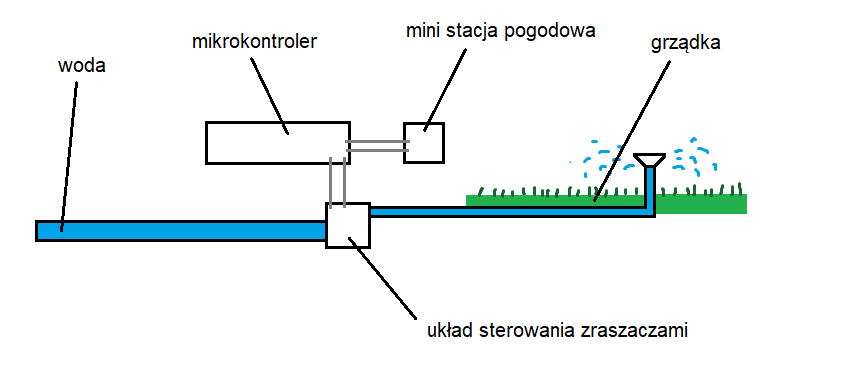

System jest sterowany elektronicznie i jest do niego podłączony higrometr (mierzący wilgotność względną w zakresie od 0% do 100%) i termometr. Temperatury są mierzone wyłącznie za dnia i znajdują się w zakresie 15°C - 35°C.Proszę zaprojektować układ rozmytego sterowania, układając reguły na podstawie następującej tabelki:

|  | Sucho | Przeciętnie | Mokro |
| --- | --- | --- | --- |
| **Chłodno** | Podlewaj średnio | Podlewaj średnio | Podlewaj mało |
| **Ciepło** | Podlewaj dużo | Podlewaj średnio | Podlewaj mało |
| **Gorąco** | Podlewaj dużo | Podlewaj dużo | Podlewaj średnio |

Proszę samodzielnie zaproponować rozmyte funkcje przynależności i narysować je na wykresach. Proszę przedstawić heatmapę wynikowej funkcji ilości wody używanej dziennie w zależności od wilgotności i temperatury ukrytej w mechanizmie sterowania.

```python
!pip install scikit-fuzzy
```

```python
import skfuzzy as fuzz
from skfuzzy import control as ctrl
import numpy as np
import matplotlib.pyplot as plt
```

```python
wilgotnosc = ctrl.Antecedent(np.arange(0, 100, 1), 'wilgotnosc')
temperatura = ctrl.Antecedent(np.arange(15, 35, 0.25), 'temperatura')
podlewanie = ctrl.Consequent(np.arange(0, 25, 0.1), 'podlewanie')

wilgotnosc['sucho'] = fuzz.trapmf(wilgotnosc.universe, [0,0,58,85])
wilgotnosc['przecietnie'] = fuzz.trapmf(wilgotnosc.universe, [40,60,85,95])
wilgotnosc['mokro'] = fuzz.trapmf(wilgotnosc.universe, [80,90,100,100])

temperatura['chlodno'] = fuzz.trapmf(temperatura.universe, [15,15,19.5,23])
temperatura['cieplo'] = fuzz.trapmf(temperatura.universe, [18,20,27,30])
temperatura['goraco'] = fuzz.trapmf(temperatura.universe, [25,27.5,35,35])

podlewanie['malo'] = fuzz.trapmf(podlewanie.universe, [0,0,5,9])
podlewanie['srednio'] = fuzz.trapmf(podlewanie.universe, [5,7,15,22])
podlewanie['duzo'] = fuzz.trapmf(podlewanie.universe, [15,20,25,25])
```

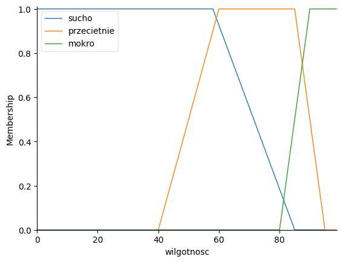

```python
wilgotnosc.view()
```

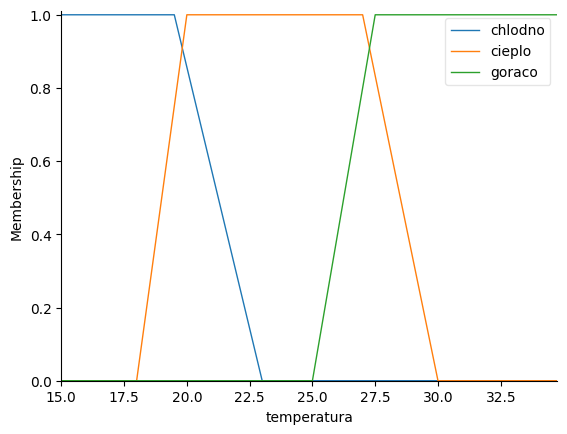

```python
temperatura.view()
```

|  | Sucho | Przeciętnie | Mokro |
| --- | --- | --- | --- |
| **Chłodno** | Podlewaj średnio | Podlewaj średnio | Podlewaj mało |
| **Ciepło** | Podlewaj dużo | Podlewaj średnio | Podlewaj mało |
| **Gorąco** | Podlewaj dużo | Podlewaj dużo | Podlewaj średnio |

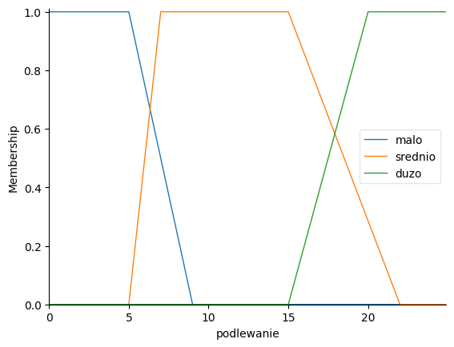

```python
podlewanie.view()
```

```python
rule1 = ctrl.Rule(
    (wilgotnosc['sucho'] & temperatura['cieplo']) | (wilgotnosc['sucho'] & temperatura['goraco']) | (wilgotnosc['przecietnie'] & temperatura['goraco']),
    podlewanie['duzo'])
rule2 = ctrl.Rule(
    (wilgotnosc['sucho'] & temperatura['chlodno']) | (wilgotnosc['przecietnie'] & temperatura['chlodno']) | (wilgotnosc['przecietnie'] & temperatura['cieplo']) | (wilgotnosc['mokro'] & temperatura['goraco']),
    podlewanie['srednio'])
rule3 = ctrl.Rule(
    (wilgotnosc['mokro'] & temperatura['cieplo']) | (wilgotnosc['mokro'] & temperatura['chlodno']),
    podlewanie['malo'])
```

```python
control_system = ctrl.ControlSystem([rule1, rule2, rule3])
model = ctrl.ControlSystemSimulation(control_system)
```

```
Model proponuje podlewanie wody o ilosci: 16.78284409654273
```

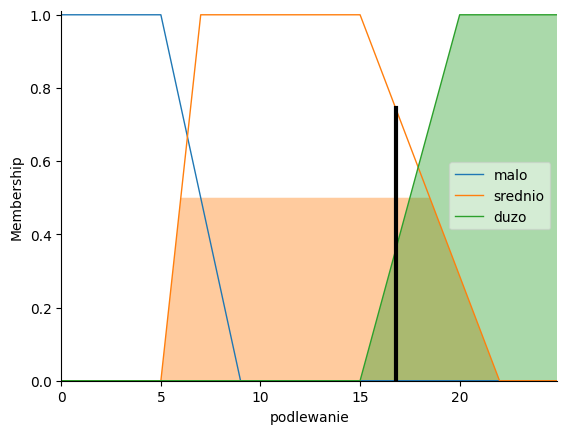

```python
model.input['wilgotnosc'] = 50
model.input['temperatura'] = 25
model.compute()
print(f'Model proponuje podlewanie wody o ilosci: {model.output["podlewanie"]}')
podlewanie.view(sim = model)
```

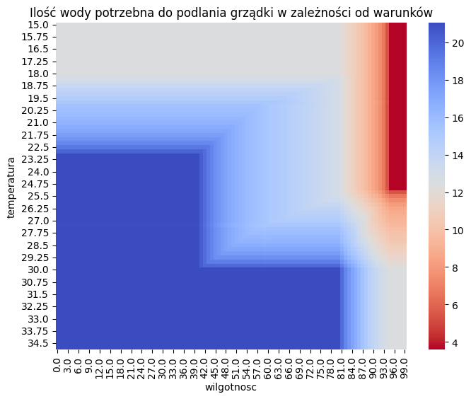

```python
import seaborn as sns
import pandas as pd

plt.figure(figsize=(8,6))
temperatura_grid, wilgotnosc_grid = np.meshgrid(np.arange(15, 35, 0.25), np.arange(0, 100, 1))
test_points = np.transpose(np.vstack((np.ravel(wilgotnosc_grid),np.ravel(temperatura_grid))))
model.input['wilgotnosc'] = test_points[:,0]
model.input['temperatura'] = test_points[:,1]
model.compute()
test_points = np.concatenate((test_points, model.output['podlewanie'].reshape(-1,1)), axis=1)
sns.heatmap(pd.DataFrame(test_points, columns = ['wilgotnosc','temperatura','podlewanie']).pivot(index='temperatura', columns='wilgotnosc', values='podlewanie'), cmap = 'coolwarm_r')
plt.title('Ilość wody potrzebna do podlania grządki w zależności od warunków')
plt.show()
```

## Wnioski

Udało się odwzorować dane z tabeli podanej w zadaniu. Heatmapa ukazuje płynne przejścia między różnymi poziomami podlewania, co potwierdza poprawne działanie systemu. Największym wyzwaniem w procesie projektowania było precyzyjne dobranie parametrów funkcji przynależności (trapezoidalnych) dla zmiennych wejściowych - wilgotności i temperatury.  
Tabela z zadania:

|  | Sucho | Przeciętnie | Mokro |
| --- | --- | --- | --- |
| **Chłodno** | Podlewaj średnio | Podlewaj średnio | Podlewaj mało |
| **Ciepło** | Podlewaj dużo | Podlewaj średnio | Podlewaj mało |
| **Gorąco** | Podlewaj dużo | Podlewaj dużo | Podlewaj średnio |

# ZAD 2

Proszę zaproponować rozmyty system wnioskowania dla dowolnego wybranego (ale różnego od poruszanych dotychczas) problemu. Proszę wziąć pod uwagę co najmniej trzy zmienne wejściowe i każdą zmienną podzielić na co najmniej trzy zbiory rozmyte. Proszę stworzyć co najmniej 5 reguł i skomentować wyniki.

Im rzadziej Państwa pomysły będą się powtarzać, tym lepiej.

## Temat : System określania ceny biletu lotniczego z Krakowa do Rzymu

Wartości miesięcy zostały celowo przesunięte w zakresie od 3 do 15, aby uwzględnić wysoki sezon zimowy, który przypada na przełom roku. Dlatego wejściowe wartości miesięcy będą mapowane na odpowiednie wartości w tym zakresie.

```python
dni_do_wylotu = ctrl.Antecedent(np.linspace(0, 365, 366), 'dni_do_wylotu')
miesiac = ctrl.Antecedent(np.linspace(3, 15, int((15 - 3) / 0.05) + 1), 'miesiac')
dzien_tygodnia = ctrl.Antecedent(np.linspace(1, 7, int((7 - 1) / 0.05) + 1), 'dzien_tygodnia')
cena = ctrl.Consequent(np.arange(150, 700, 0.5), 'cena')

dni_do_wylotu['malo'] = fuzz.trapmf(dni_do_wylotu.universe, [0, 0, 7, 14])
dni_do_wylotu['srednio'] = fuzz.trapmf(dni_do_wylotu.universe, [7, 14, 60, 90])
dni_do_wylotu['duzo'] = fuzz.trapmf(dni_do_wylotu.universe, [60, 90, 180, 290])
dni_do_wylotu['bardzo_duzo'] = fuzz.trapmf(dni_do_wylotu.universe, [180, 240, 365, 365])

miesiac['niski_sezon_wiosenny'] = fuzz.trapmf(miesiac.universe, [3, 3, 5.8,6.9 ])
miesiac['niski_sezon_jesienny'] = fuzz.trapmf(miesiac.universe, [9,9.9, 11.9, 13 ])
miesiac['wakacje'] = fuzz.trapmf(miesiac.universe, [5, 6.5, 9, 10.5])
miesiac['wysoki_sezon'] = fuzz.trapmf(miesiac.universe, [11, 12, 15, 15])

dzien_tygodnia['dni_pracy'] = fuzz.trapmf(dzien_tygodnia.universe, [1, 1, 4.5, 5])
dzien_tygodnia['przed_weekendem'] = fuzz.trapmf(dzien_tygodnia.universe, [3, 5, 5.8, 7])
dzien_tygodnia['w_trakcie_weekendu'] = fuzz.trapmf(dzien_tygodnia.universe, [5, 6, 7, 7])

cena['niska'] = fuzz.trapmf(cena.universe, [150, 150, 250, 350])  # 150–350 PLN
cena['srednia'] = fuzz.trapmf(cena.universe, [250, 350, 450, 550])  # 350–550 PLN
cena['wysoka'] = fuzz.trapmf(cena.universe, [450, 550, 700, 700])
```

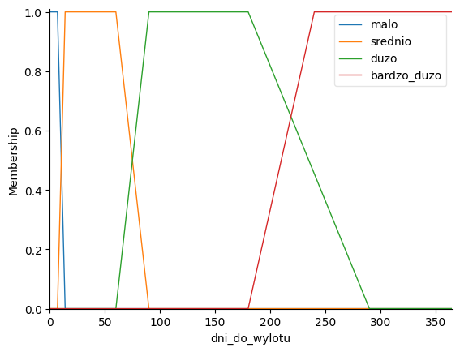

```python
dni_do_wylotu.view()
```

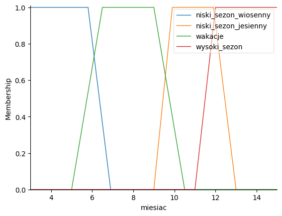

```python
miesiac.view()
```

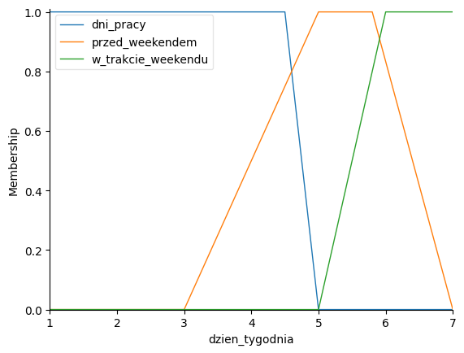

```python
dzien_tygodnia.view()
```

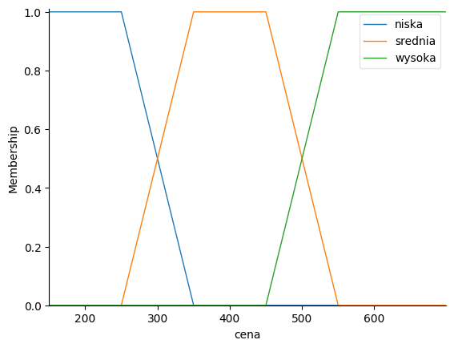

```python
cena.view()
```

```python
rule1 = ctrl.Rule(dni_do_wylotu['duzo'] & miesiac['niski_sezon_wiosenny'] & dzien_tygodnia['dni_pracy'], cena['niska'])
rule2 = ctrl.Rule(dni_do_wylotu['duzo'] & miesiac['niski_sezon_jesienny'] & dzien_tygodnia['dni_pracy'], cena['niska'])
rule3 = ctrl.Rule(dni_do_wylotu['bardzo_duzo'] & miesiac['niski_sezon_wiosenny'], cena['niska'])
rule4 = ctrl.Rule(dni_do_wylotu['bardzo_duzo'] & miesiac['niski_sezon_jesienny'], cena['niska'])

rule5 = ctrl.Rule(dni_do_wylotu['srednio'] & miesiac['niski_sezon_wiosenny'], cena['srednia'])
rule6 = ctrl.Rule(dni_do_wylotu['srednio'] & miesiac['niski_sezon_jesienny'], cena['srednia'])
rule7 = ctrl.Rule(dni_do_wylotu['duzo'] & miesiac['wakacje'] & dzien_tygodnia['dni_pracy'], cena['srednia'])
#rule8 = ctrl.Rule(dni_do_wylotu['srednio'] & miesiac['wysoki_sezon'] & dzien_tygodnia['dni_pracy'], cena['srednia'])
rule8 = ctrl.Rule(dni_do_wylotu['malo'] & miesiac['niski_sezon_wiosenny'], cena['srednia'])
rule9 = ctrl.Rule(dni_do_wylotu['malo'] & miesiac['niski_sezon_jesienny'], cena['srednia'])
rule13 = ctrl.Rule(dni_do_wylotu['bardzo_duzo'] & miesiac['wakacje'], cena['srednia'])
rule15 = ctrl.Rule(dni_do_wylotu['bardzo_duzo'] & miesiac['wysoki_sezon'], cena['srednia'])

rule10 = ctrl.Rule(dni_do_wylotu['malo'] & miesiac['wakacje'] & dzien_tygodnia['w_trakcie_weekendu'], cena['wysoka'])
#rule11 = ctrl.Rule(dni_do_wylotu['srednio'] & miesiac['wysoki_sezon'] & dzien_tygodnia['przed_weekendem'], cena['wysoka'])
#rule12 = ctrl.Rule(dni_do_wylotu['malo'] & miesiac['wysoki_sezon'], cena['wysoka'])
#rule13 = ctrl.Rule(dni_do_wylotu['duzo'] & miesiac['wakacje'] & dzien_tygodnia['przed_weekendem'], cena['wysoka'])

rule14 = ctrl.Rule(dni_do_wylotu['duzo'], cena['srednia'])
rule11 = ctrl.Rule(miesiac['wysoki_sezon'], cena['wysoka'])
rule12 = ctrl.Rule(dzien_tygodnia['przed_weekendem'], cena['wysoka'])
```

```python
def mapuj_miesiac(miesiac):
    if miesiac == 1:
        return 13
    elif miesiac == 2:
        return 14
    elif miesiac == 3:
        return 15
    else:
        return miesiac
```

Przykładowe przypadki z przedziałów granicznych. Spodziewamy się wysokiej ceny i niskiej.

```python
control_system = ctrl.ControlSystem([rule1, rule2, rule3, rule4, rule5, rule6, rule7,rule8, rule9, rule10, rule11,rule12,rule13,rule14,rule15])
model = ctrl.ControlSystemSimulation(control_system)

def test_scenario(days, month, day_of_week):
    model.input['dni_do_wylotu'] = days
    model.input['miesiac'] = mapuj_miesiac(month)
    model.input['dzien_tygodnia'] = day_of_week
    model.compute()
    print(f"Input: {days} days, month {month}, day {day_of_week} → Price: {model.output['cena']:.2f} PLN")

test_scenario(5, 8, 6)
test_scenario(300, 4, 2)
```

```
Input: 5 days, month 8, day 6 → Price: 597.66 PLN
Input: 300 days, month 4, day 2 → Price: 227.78 PLN
```

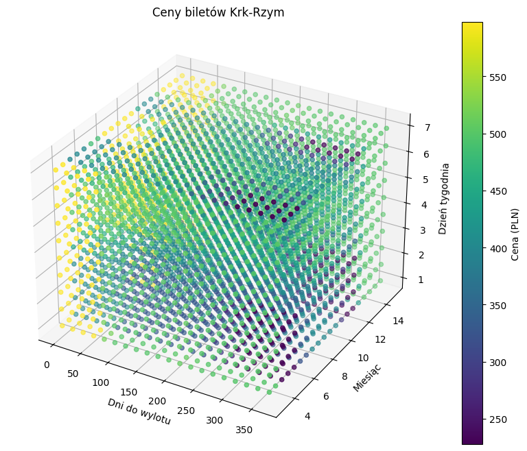

```python
dni_range = np.linspace(0, 365, 20)
miesiac_range = np.linspace(3, 15, 20)
dzien_range = np.linspace(1, 7, 10)

X, Y, Z = np.meshgrid(dni_range, miesiac_range, dzien_range)
prices = np.zeros(X.shape)

for i in range(X.shape[0]):
    for j in range(X.shape[1]):
        for k in range(X.shape[2]):
            model.input['dni_do_wylotu'] = X[i, j, k]
            model.input['miesiac'] = mapuj_miesiac(int(Y[i, j, k]))
            model.input['dzien_tygodnia'] = Z[i, j, k]
            try:
                model.compute()
                prices[i, j, k] = model.output['cena']
            except:
                prices[i, j, k] = np.nan

fig = plt.figure(figsize=(12, 8))
ax = fig.add_subplot(111, projection='3d')

scat = ax.scatter(X.flatten(), Y.flatten(), Z.flatten(), c=prices.flatten(), cmap='viridis', s=20)

fig.colorbar(scat, ax=ax, label='Cena (PLN)')
ax.set_xlabel('Dni do wylotu')
ax.set_ylabel('Miesiąc')
ax.set_zlabel('Dzień tygodnia')

plt.title('Ceny biletów Krk-Rzym')
plt.show()
```

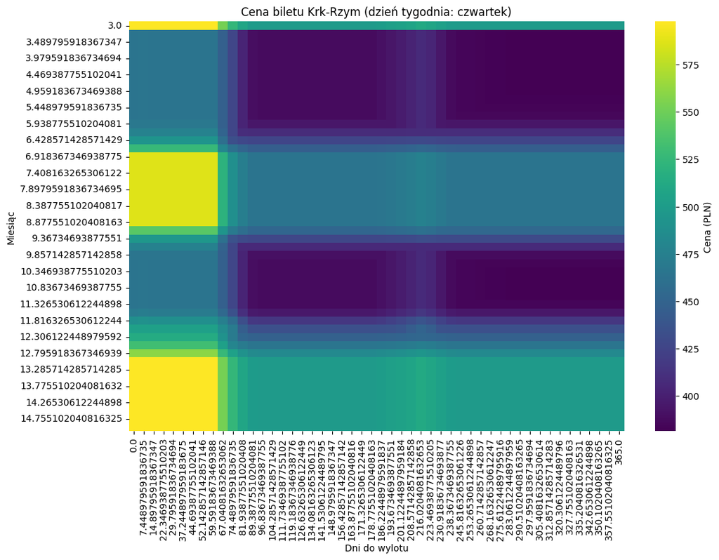

```python
plt.figure(figsize=(12, 8))
dni_mesh, miesiac_mesh = np.meshgrid(np.linspace(0, 365,50), np.linspace(3, 15,50))

ceny = []
for dni, miesiac in zip(np.ravel(dni_mesh), np.ravel(miesiac_mesh)):
    model.input['dni_do_wylotu'] = dni
    model.input['miesiac'] = mapuj_miesiac(miesiac)
    model.input['dzien_tygodnia'] = 4
    try:
        model.compute()
        ceny.append(model.output['cena'])
    except:
        ceny.append(np.nan)

ceny_grid = np.array(ceny).reshape(dni_mesh.shape)
sns.heatmap(
    pd.DataFrame(np.column_stack((dni_mesh.ravel(), miesiac_mesh.ravel(), ceny)), columns=['dni_do_wylotu', 'miesiac', 'cena']).pivot(index='miesiac', columns='dni_do_wylotu', values='cena'),
    cmap='viridis',
    cbar_kws={'label': 'Cena (PLN)'}
)
plt.title('Cena biletu Krk-Rzym (dzień tygodnia: czwartek)')
plt.xlabel('Dni do wylotu')
plt.ylabel('Miesiąc')
plt.show()
```